# Analyzing crime data in Los Angeles, California (2020-2022)

Madi Zhaksylyk

Due: 3/3/2023

Studying crime data can offer valuable information about the patterns and trends in criminal behavior, including the timing and locations of crimes, the most prevalent types of crimes, and the demographics of those who are most frequently victimized. This data can help guide law enforcement tactics, inform strategies for preventing crime, and aid in allocating resources effectively.

### 1. Dataset

The dataset I am going to use in this project is on crime incidents in Los Angeles, California, during January 1, 2020 and February 20, 2023. The dataset was downloaded from US Government’s open data website (data.gov) and can be found here: https://catalog.data.gov/dataset/crime-data-from-2020-to-present. Description of the variables can be found here: https://data.lacity.org/Public-Safety/Crime-Data-from-2020-to-Present/2nrs-mtv8.

```r
#reading the file
crime <- read.csv("C:/CMU Heinz College/Spring 2023/Programming R for Analytics 94842 A3/final project/Crime_Data_from_2020_to_Present.csv", stringsAsFactors=TRUE)
```

Prior to conducting any meaningful analysis, my first step is to explore the data to get an overview of the dataset.

### 2. Exploratory Data Analysis and Cleaning the Data

```r
str(crime)
```

```
## 'data.frame':    668881 obs. of  28 variables:
##  $ DR_NO         : int  10304468 190101086 200110444 191501505 191921269 200100501 200100502 200100504 200100507 201710201 ...
##  $ Date.Rptd     : Factor w/ 1147 levels "01/01/2020 12:00:00 AM",..: 29 5 362 1 1 5 5 13 13 560 ...
##  $ DATE.OCC      : Factor w/ 1147 levels "01/01/2020 12:00:00 AM",..: 29 1 173 1 1 1 5 13 13 488 ...
##  $ TIME.OCC      : int  2230 330 1200 1730 415 30 1315 40 200 1925 ...
##  $ AREA          : int  3 1 1 15 19 1 1 1 1 17 ...
##  $ AREA.NAME     : Factor w/ 21 levels "77th Street",..: 16 2 2 9 8 2 2 2 2 3 ...
##  $ Rpt.Dist.No   : int  377 163 155 1543 1998 163 161 155 101 1708 ...
##  $ Part.1.2      : int  2 2 2 2 2 1 1 2 1 1 ...
##  $ Crm.Cd        : int  624 624 845 745 740 121 442 946 341 341 ...
##  $ Crm.Cd.Desc   : Factor w/ 137 levels "ARSON","ASSAULT WITH DEADLY WEAPON ON POLICE OFFICER",..: 5 5 100 130 129 95 105 84 111 111 ...
##  $ Mocodes       : Factor w/ 229394 levels "","0100","0100 0104",..: 78295 69622 162080 16603 11842 62393 158726 153501 184043 140366 ...
##  $ Vict.Age      : int  36 25 0 76 31 25 23 0 23 0 ...
##  $ Vict.Sex      : Factor w/ 5 levels "","F","H","M",..: 2 4 5 2 5 2 4 5 4 5 ...
##  $ Vict.Descent  : Factor w/ 20 levels "","A","B","C",..: 3 8 19 18 19 8 8 19 3 19 ...
##  $ Premis.Cd     : int  501 102 726 502 409 735 404 726 502 203 ...
##  $ Premis.Desc   : Factor w/ 307 levels "","7TH AND METRO CENTER (NOT LINE SPECIFIC)",..: 257 256 237 209 25 214 57 237 209 220 ...
##  $ Weapon.Used.Cd: int  400 500 NA NA NA 500 NA NA NA NA ...
##  $ Weapon.Desc   : Factor w/ 80 levels "","AIR PISTOL/REVOLVER/RIFLE/BB GUN",..: 67 77 1 1 1 77 1 1 1 1 ...
##  $ Status        : Factor w/ 6 levels "AA","AO","CC",..: 2 4 1 4 4 4 4 4 4 2 ...
##  $ Status.Desc   : Factor w/ 6 levels "Adult Arrest",..: 2 3 1 3 3 3 3 3 3 2 ...
##  $ Crm.Cd.1      : int  624 624 845 745 740 121 442 946 341 341 ...
##  $ Crm.Cd.2      : int  NA NA NA 998 NA 998 998 998 998 NA ...
##  $ Crm.Cd.3      : int  NA NA NA NA NA NA NA NA NA NA ...
##  $ Crm.Cd.4      : int  NA NA NA NA NA NA NA NA NA NA ...
##  $ LOCATION      : Factor w/ 60874 levels "00    17TH","00    17TH                         AV",..: 4946 44616 21053 38775 12887 44580 44603 21053 44044 7002 ...
##  $ Cross.Street  : Factor w/ 9023 levels "","10                           FY",..: 1 1 1 1 1 1 1 1 1 1 ...
##  $ LAT           : num  34 34 34 34.2 34.2 ...
##  $ LON           : num  -118 -118 -118 -118 -118 ...
```

The original dataset contains of 668881 observations across 28 variables which should be sufficient to find patterns, explore relationships and draw some insights from it. However, it is helpful to check if all the columns have a decent share of non-missing values.

```r
library(tidyverse)
round(apply(crime, 2, function(col)sum(is.na(col))/length(col))*100, 1)
```

```
##          DR_NO      Date.Rptd       DATE.OCC       TIME.OCC           AREA
##            0.0            0.0            0.0            0.0            0.0
##      AREA.NAME    Rpt.Dist.No       Part.1.2         Crm.Cd    Crm.Cd.Desc
##            0.0            0.0            0.0            0.0            0.0
##        Mocodes       Vict.Age       Vict.Sex   Vict.Descent      Premis.Cd
##            0.0            0.0            0.0            0.0            0.0
##    Premis.Desc Weapon.Used.Cd    Weapon.Desc         Status    Status.Desc
##            0.0           65.2            0.0            0.0            0.0
##       Crm.Cd.1       Crm.Cd.2       Crm.Cd.3       Crm.Cd.4       LOCATION
##            0.0           92.5           99.7          100.0            0.0
##   Cross.Street            LAT            LON
##            0.0            0.0            0.0
```

```r
# modified the code from StackOverflow: https://stackoverflow.com/questions/23597140/how-to-find-the-percentage-of-nas-in-a-data-frame
```

It turns out that some columns have a lot of missing values. Those columns may be dropped from the dataset: “Weapon.Used.Cd” - 65.2%, “Crm.Cd.2” - 92.5%, “Crm.Cd.3” - 99.7%, “Crm.Cd.4” - 100%. Dropping these columns should not affect the quality of the analysis: - Weapon.Used.Cd is coded weapon type which I will not need since there is a categorical variable with informative description of the weapon type; - Crm.Cd.2, Crm.Cd.3, Crm.Cd.4 are the codes for additional crimes (if applicable), less serious than Crm.Cd.1. Although they may be of some interest, my project will focus only on primary crimes. There are also columns which are redundant within the scope of this project: “Part.1.2” and “Mocodes”. “Crm.Cd.1” duplicates the values in “Crm.Cd”, “Status.Desc” is a longer version of “Status”.

```r
crime = subset(crime, select = -c(Weapon.Used.Cd, Crm.Cd.1, Crm.Cd.2, Crm.Cd.3, Crm.Cd.4, Part.1.2, Mocodes, Status.Desc))
```

Formatting and renaming some of the columns will make my data easier to interpret.

```r
colnames(crime)
```

```
##  [1] "DR_NO"        "Date.Rptd"    "DATE.OCC"     "TIME.OCC"     "AREA"
##  [6] "AREA.NAME"    "Rpt.Dist.No"  "Crm.Cd"       "Crm.Cd.Desc"  "Vict.Age"
## [11] "Vict.Sex"     "Vict.Descent" "Premis.Cd"    "Premis.Desc"  "Weapon.Desc"
## [16] "Status"       "LOCATION"     "Cross.Street" "LAT"          "LON"
```

```r
library(dplyr)
crime <- crime %>% rename("record_no" = "DR_NO", "date_rep" = "Date.Rptd", "date_occ" = "DATE.OCC",
                          "time_occ" = "TIME.OCC", "area_no" = "AREA", "area_name" = "AREA.NAME",
                          "dist_no" = "Rpt.Dist.No", "crime_code" = "Crm.Cd", "crime_desc" = "Crm.Cd.Desc",
                          "v_age" = "Vict.Age", "v_sex" = "Vict.Sex", "v_descent" = "Vict.Descent",
                    "premise_code" = "Premis.Cd", "premise_desc" = "Premis.Desc", "weapon" = "Weapon.Desc",
                          "case_status" = "Status", "location" = "LOCATION", "cross_str" = "Cross.Street",
                          "latitude" = "LAT", "longitude" = "LON")
colnames(crime)
```

```
##  [1] "record_no"    "date_rep"     "date_occ"     "time_occ"     "area_no"
##  [6] "area_name"    "dist_no"      "crime_code"   "crime_desc"   "v_age"
## [11] "v_sex"        "v_descent"    "premise_code" "premise_desc" "weapon"
## [16] "case_status"  "location"     "cross_str"    "latitude"     "longitude"
```

Some columns have inappropriate data types, so it is better to convert them (e.g. area_no is integer, which I want to be categorical variable). I also need to convert the date columns in order to properly use it in time series analysis.

```r
crime$area_no <- as.factor(crime$area_no)
crime$dist_no <- as.factor(crime$dist_no)
crime$crime_code <- as.factor(crime$crime_code)
crime$premise_code <- as.factor(crime$premise_code)
crime$date_rep <- as.Date(crime$date_rep, format="%m/%d/%Y")
crime$date_occ <- as.Date(crime$date_occ, format="%m/%d/%Y")
crime$time_occ <- format(strptime(substr(as.POSIXct(sprintf("%04.0f", crime$time_occ), format="%H%M"), 12, 16), '%H:%M'), '%I:%M %p')
# modified the code from StackOverflow: https://stackoverflow.com/questions/38433156/convert-military-time-to-standard-time-with-hours-and-minutes-in-r

crime <- crime[crime$v_age >= 18, ]
crime <- crime[crime$v_sex != 'H', ]
crime <- crime[crime$v_sex != '', ]
crime$v_sex <- droplevels(crime$v_sex)
# looked up how to drop unnecessary levels here: https://www.statology.org/droplevels-r/

crime <- crime %>% filter(date_occ < '2023-01-01')
summary(crime)
```

```
##    record_no            date_rep             date_occ
##  Min.   : 10304468   Min.   :2020-01-01   Min.   :2020-01-01
##  1st Qu.:201814091   1st Qu.:2020-10-29   1st Qu.:2020-10-17
##  Median :211315132   Median :2021-08-18   Median :2021-08-06
##  Mean   :211920285   Mean   :2021-07-31   Mean   :2021-07-21
##  3rd Qu.:220711510   3rd Qu.:2022-05-06   3rd Qu.:2022-04-26
##  Max.   :232105835   Max.   :2023-02-20   Max.   :2022-12-31
##
##    time_occ            area_no             area_name         dist_no
##  Length:468636      1      : 33152   Central    : 33152   162    :  2548
##  Class :character   12     : 29531   77th Street: 29531   182    :  2357
##  Mode  :character   3      : 29170   Southwest  : 29170   645    :  2217
##                     14     : 26520   Pacific    : 26520   646    :  2156
##                     6      : 25960   Hollywood  : 25960   636    :  2087
##                     18     : 23481   Southeast  : 23481   111    :  1897
##                     (Other):300822   (Other)    :300822   (Other):455374
##    crime_code
##  624    : 47509
##  354    : 39433
##  330    : 39138
##  230    : 34142
##  626    : 32069
##  740    : 29986
##  (Other):246359
##                                                    crime_desc
##  BATTERY - SIMPLE ASSAULT                               : 47509
##  THEFT OF IDENTITY                                      : 39433
##  BURGLARY FROM VEHICLE                                  : 39138
##  ASSAULT WITH DEADLY WEAPON, AGGRAVATED ASSAULT         : 34142
##  INTIMATE PARTNER - SIMPLE ASSAULT                      : 32069
##  VANDALISM - FELONY ($400 & OVER, ALL CHURCH VANDALISMS): 29986
##  (Other)                                                :246359
##      v_age       v_sex        v_descent       premise_code
##  Min.   :18.00   F:224404   H      :182771   501    :101406
##  1st Qu.:29.00   M:238916   W      :121588   101    : 86615
##  Median :37.00   X:  5316   B      : 88403   502    : 70998
##  Mean   :40.52              O      : 41925   108    : 31336
##  3rd Qu.:51.00              A      : 13499   102    : 25243
##  Max.   :99.00              X      :  9529   122    : 18422
##                             (Other): 10921   (Other):134616
```

[output cut: 17 more lines]

```
##  7TH                                   :   930
##  6TH                                   :   879
##  800 N  ALAMEDA                      ST:   871
##  6TH                          ST       :   835
##  7TH                          ST       :   797
##  5TH                                   :   741
##  (Other)                               :463583
##                            cross_str         latitude       longitude
##                                 :391112   Min.   : 0.00   Min.   :-118.7
##  BROADWAY                       :  1253   1st Qu.:34.02   1st Qu.:-118.4
##  FIGUEROA                     ST:   898   Median :34.06   Median :-118.3
##  SAN PEDRO                      :   821   Mean   :33.95   Mean   :-117.9
##  FIGUEROA                       :   820   3rd Qu.:34.16   3rd Qu.:-118.3
##  VERMONT                      AV:   816   Max.   :34.33   Max.   :   0.0
##  (Other)                        : 72916
```

Now that I have cleaned my dataset, it is time to look for insights.

### 3. Analysis of Crimes Incidents by Victim Age and Descent

```r
top10_crimes <- head(sort(table(crime$crime_desc), decreasing = TRUE), 10)
top10_premises <- head(sort(table(crime$premise_desc), decreasing = TRUE), 10)
top10_crimes <- as.data.frame(top10_crimes)
top10_crimes
```

```
##                                                       Var1  Freq
## 1                                 BATTERY - SIMPLE ASSAULT 47509
## 2                                        THEFT OF IDENTITY 39433
## 3                                    BURGLARY FROM VEHICLE 39138
## 4           ASSAULT WITH DEADLY WEAPON, AGGRAVATED ASSAULT 34142
## 5                        INTIMATE PARTNER - SIMPLE ASSAULT 32069
## 6  VANDALISM - FELONY ($400 & OVER, ALL CHURCH VANDALISMS) 29986
## 7                       THEFT PLAIN - PETTY ($950 & UNDER) 28585
## 8                                                 BURGLARY 26673
## 9      THEFT FROM MOTOR VEHICLE - GRAND ($950.01 AND OVER) 21029
## 10                                                 ROBBERY 17081
```

```r
top10_premises
```

```
##
##                       SINGLE FAMILY DWELLING
##                                       101406
##                                       STREET
##                                        86615
## MULTI-UNIT DWELLING (APARTMENT, DUPLEX, ETC)
##                                        70998
##                                  PARKING LOT
##                                        31336
##                                     SIDEWALK
##                                        25243
##                     VEHICLE, PASSENGER/TRUCK
##                                        18422
##                               OTHER BUSINESS
##                                        14946
##                               GARAGE/CARPORT
##                                        10203
##                                     DRIVEWAY
##                                         7962
##                 PARKING UNDERGROUND/BUILDING
##                                         5405
```

Top 10 crime types by frequency include: battery, theft of identity, burglary, vandalism, various kinds of assaults and thefts. The most frequent premises are single family and multi-unit dwellings, streets, driveways and sidewalks, and parking lots and garages.

```r
table(crime$v_descent)
```

```
##
##             A      B      C      D      F      G      H      I      J      K
##      2  13499  88403   2282     44   2527     44 182771    582    845   3345
##      L      O      P      S      U      V      W      X      Z
##     35  41925    161     30    101    622 121588   9529    301
```

```r
table(crime$v_sex)
```

```
##
##      F      M      X
## 224404 238916   5316
```

```r
mean(crime$v_age)
```

```
## [1] 40.51593
```

```r
median(crime$v_age)
```

```
## [1] 37
```

```r
crime %>%
  group_by(v_sex) %>%
  summarize(mean_age = mean(v_age), median_age = median(v_age))
```

```
## # A tibble: 3 × 3
##   v_sex mean_age median_age
##   <fct>    <dbl>      <dbl>
## 1 F         39.8         36
## 2 M         41.6         39
## 3 X         24.1         21
```

```r
crime %>%
  group_by(v_descent) %>%
  summarize(mean_age = mean(v_age), median_age = median(v_age))
```

```
## # A tibble: 20 × 3
##    v_descent mean_age median_age
##    <fct>        <dbl>      <dbl>
##  1 ""            22         22
##  2 "A"           42.6       39
##  3 "B"           40.4       37
##  4 "C"           35.0       31
##  5 "D"           32.8       33
##  6 "F"           40.1       37
##  7 "G"           39.9       38.5
##  8 "H"           38.4       36
##  9 "I"           36.3       33
## 10 "J"           44.5       43
## 11 "K"           42.2       38
## 12 "L"           34.9       34
## 13 "O"           42.3       40
## 14 "P"           39.5       36
## 15 "S"           39.6       33.5
## 16 "U"           35.9       34
## 17 "V"           35.5       33
## 18 "W"           43.9       41
## 19 "X"           30.1       26
## 20 "Z"           36.3       33
```

```r
male_age <- crime$v_age[crime$v_sex == "M"]
female_age <- crime$v_age[crime$v_sex == "F"]
t.test(male_age, female_age)
```

```
##
##  Welch Two Sample t-test
##
## data:  male_age and female_age
## t = 41.025, df = 461022, p-value < 2.2e-16
## alternative hypothesis: true difference in means is not equal to 0
## 95 percent confidence interval:
##  1.705844 1.877015
## sample estimates:
## mean of x mean of y
##  41.57236  39.78093
```

```r
descent1_anova <- aov(v_age[v_descent == c('A', 'B', 'H', 'W')] ~ v_descent[v_descent == c('A', 'B', 'H', 'W')], data = crime)
summary(descent1_anova)
```

```
##                                                   Df   Sum Sq Mean Sq F value
## v_descent[v_descent == c("A", "B", "H", "W")]      3   588049  196016   907.8
## Residuals                                     101584 21934524     216
##                                               Pr(>F)
## v_descent[v_descent == c("A", "B", "H", "W")] <2e-16 ***
## Residuals
## ---
## Signif. codes:  0 '***' 0.001 '**' 0.01 '*' 0.05 '.' 0.1 ' ' 1
```

```r
TukeyHSD(descent1_anova)
```

```
##   Tukey multiple comparisons of means
##     95% family-wise confidence level
##
## Fit: aov(formula = v_age[v_descent == c("A", "B", "H", "W")] ~ v_descent[v_descent == c("A", "B", "H", "W")], data = crime)
##
## $`v_descent[v_descent == c("A", "B", "H", "W")]`
##          diff        lwr       upr    p adj
## B-A -2.342492 -3.0355504 -1.649434 0.00e+00
## H-A -4.347042 -5.0157576 -3.678326 0.00e+00
## W-A  1.251493  0.5711374  1.931849 1.36e-05
## H-B -2.004550 -2.3137180 -1.695382 0.00e+00
## W-B  3.593985  3.2603862  3.927584 0.00e+00
## W-H  5.598535  5.3190019  5.878068 0.00e+00
```

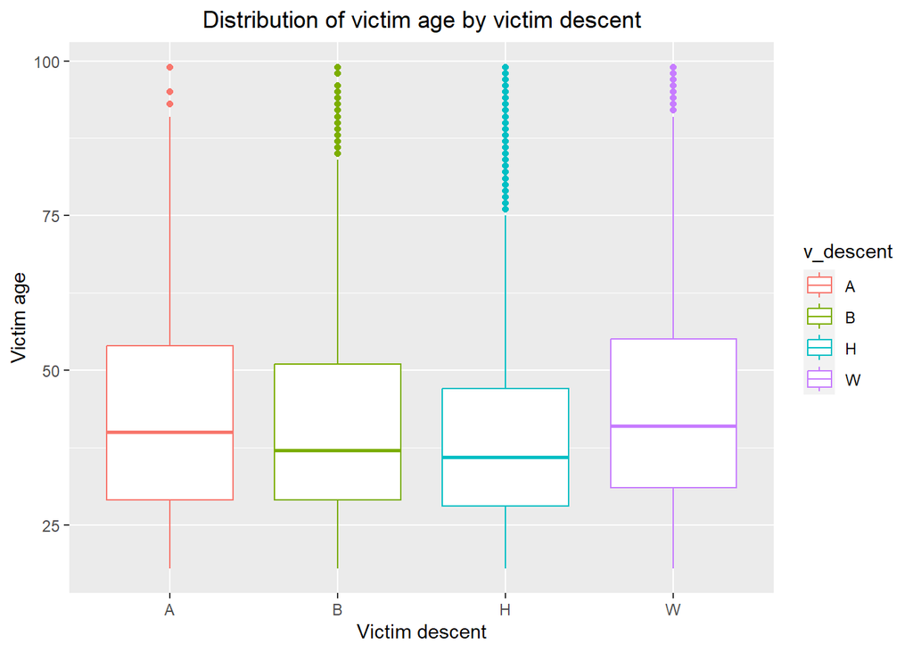

```r
crime_largest_descents <- crime %>% filter(v_descent == c('A', 'B', 'H', 'W'))
ggplot(crime_largest_descents, aes(x = v_descent, y = v_age, color = v_descent)) +
  geom_boxplot() +
  labs(title = "Distribution of victim age by victim descent", x = "Victim descent", y = "Victim age") + theme(plot.title = element_text(hjust = 0.5))
```

As expected, majority of crime incidents involve victims of White, Hispanic/Latin/Mexican and Black descents, while the distribution of incidents across sexes is relatively balanced. The mean age of the victims is 40.5 and the median is 37 years. However, there are significant age differences across male vs female and across descents (I did ANOVA on 4 largest descent groups).

### 4. Time-Series Analysis of Crime Incidents

```r
crime %>%
    mutate(year = format(as.Date(date_occ), "%Y")) %>%
    count(year)
```

```
##   year      n
## 1 2020 145339
## 2 2021 153300
## 3 2022 169997
```

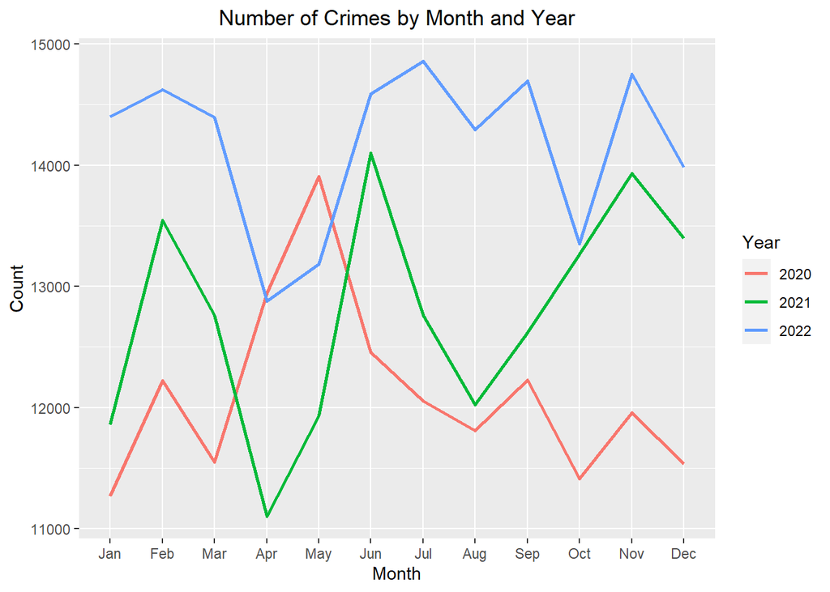

```r
by_month <- crime %>%
    mutate(month = format(as.Date(date_occ), "%Y-%m")) %>%
    count(month)

crime %>%
    mutate(year = format(as.Date(date_occ), "%Y"),
           month = format(as.Date(date_occ), "%b")) %>%
    group_by(year, month) %>%
    summarize(count = n(), .groups = "drop") %>%
    ggplot(aes(x = month, y = count, color = year, group = year)) +
    geom_line(size = 1) +
    scale_x_discrete(labels = c("Jan", "Feb", "Mar", "Apr", "May", "Jun", "Jul", "Aug", "Sep", "Oct", "Nov", "Dec")) +
    labs(title = "Number of Crimes by Month and Year", x = "Month", y = "Count", color = "Year") + theme(plot.title = element_text(hjust = 0.5))
```

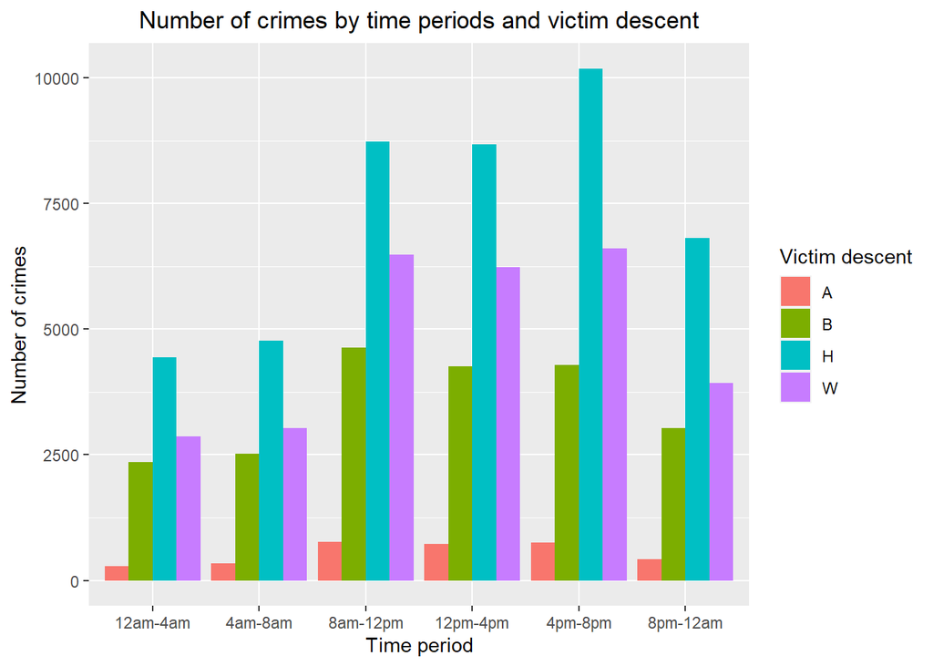

```r
times_posix <- as.POSIXct(crime_largest_descents$time_occ, format = "%I:%M %p")
#https://www.rdocumentation.org/packages/base/versions/3.6.2/topics/as.POSIX* (helped understand posix logic)

crime_largest_descents$time_chunks <- cut(as.numeric(format(times_posix, "%H")), breaks = c(0, 4, 8, 12, 16, 20, 24),
                     labels = c("12am-4am", "4am-8am", "8am-12pm", "12pm-4pm", "4pm-8pm", "8pm-12am"))

crime_largest_descents <- crime_largest_descents[complete.cases(crime_largest_descents$time_chunks), ]

ggplot(crime_largest_descents, aes(x = time_chunks, fill = v_descent)) +
    geom_bar(position = "dodge") +
    labs(title = "Number of crimes by time periods and victim descent", x = "Time period", y = "Number of crimes", fill = "Victim descent") + theme(plot.title = element_text(hjust = 0.5))
```

The histogram above shows the number of crime incidents in different time periods of the day across races. It demonstrates that time period between 4pm-8pm has the highest crime rate, and that crimes ‘against’ Hispanic people during this period are disproportionately more frequent as compared to other descent groups and time chunks.

### 5. Conclusion

This initial (baseline) examination of crime data in Los Angeles for 2020-2022 using R software revealed the most common types of crimes and premises, variations in the demographics of crime victims, and trends in crime rates over different timeframes such as year-over-year and within a day.